# Brasileirão 2017: Uma análise quantitativa

Júlio Guedes

## Import dos dados

```r
dados <- read_csv2(here::here("data/campeonato-brasileiro-full.csv"),
                   col_types="ccccccccdddccc")
```

```
## Using ',' as decimal and '.' as grouping mark. Use read_delim() for more control.
```

```r
dados <- dados %>%
  rename(
    horario = `Horario`,
    dia = `Dia`,
    data = `Data`,
    c1 = `Clube 1`,
    c2 = `Clube 2`,
    vencedor = `Vencedor`,
    rodada = `Rodada`,
    arena = `Arena`,
    p1 = `p1`,
    p2 = `p2`,
    gols = `gols`,
    c1e = `C1 Estado`,
    c2e = `C2 Estado`,
    vencedor_estado = `Vencedor Estado`
  )
```

## Análise

Nesse post, buscamos identificar a equivalência em significado do teste de hipótese via permutação e os intervalos de confiança. Entretanto, para ambas, é necessário definir quais as funções $\theta$ para nossas perguntas:

1. Jogos aos domingos têm mais gols que jogos às quartas?

```r
theta_quarta_domingo <- function(df, i) {
  jogos <- df %>% filter(dia %in% c("Quarta-feira", "Domingo")) %>%
    slice(i) %>%
    group_by(dia) %>%
    summarise(media_gols = mean(gols))

  domingo <- jogos %>% filter(dia == "Domingo") %>% pull(media_gols)
  quarta <- jogos %>% filter(dia == "Quarta-feira") %>% pull(media_gols)

  domingo - quarta
}

theta_qd <- theta_quarta_domingo(dados, 1:NROW(dados))
theta_qd
```

```
## [1] -0.01482372
```

2. Jogos onde há um vitorioso têm mais ou menos gols que empates?

```r
theta_vitoria_empate <- function(df, i) {
  jogos <- df %>%
    slice(i) %>%
    mutate(vit_emp = if_else(p1 == p2, "E", "V")) %>%
    group_by(vit_emp) %>%
    summarise(media_gols = mean(gols))

  vitoria <- jogos %>% filter(vit_emp == "V") %>% pull(media_gols)
  empate <- jogos %>% filter(vit_emp == "E") %>% pull(media_gols)

  vitoria - empate
}

theta_ve <- theta_vitoria_empate(dados, 1:NROW(dados))
theta_ve
```

```
## [1] 0.56181
```

Tendo nossas funções definidas, as utilizaremos nas duas partes da análise.

## Teste de Hipótese via permutação

### Domingo vs. Quarta

Definiremos então nossa hipótese nula para a primeira como sendo “domingos e quartas-feiras não têm diferença significante em gols”, e verificaremos o p-valor para a pergunta abaixo:

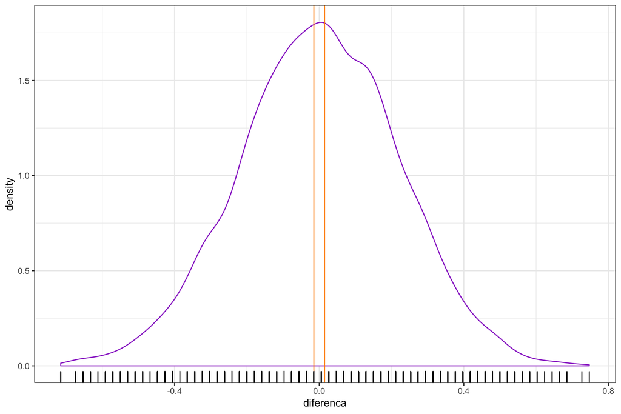

```r
theta_h_dom_qua <- function(df) {
  jogos <- df %>% filter(dia %in% c("Quarta-feira", "Domingo")) %>%
    mutate(dia_trocado = sample(dia, n())) %>%
    group_by(dia_trocado) %>%
    summarise(media_gols = mean(gols))

  domingo <- jogos %>% filter(dia_trocado == "Domingo") %>% pull(media_gols)
  quarta <- jogos %>% filter(dia_trocado == "Quarta-feira") %>% pull(media_gols)

  domingo - quarta
}

diffs1 <- replicate(5000, {theta_h_dom_qua(dados)})

tibble(diferenca = diffs1) %>%
  ggplot(mapping = aes(x = diferenca)) +
  #geom_histogram()
  geom_density(fill="white", color = "darkorchid") +
  geom_vline(xintercept = theta_qd, color = "darkorange") +
  geom_vline(xintercept = - theta_qd, color = "darkorange") +
  geom_rug()
```

```r
pvalor1 <- mean(abs(diffs1) >= abs(theta_qd))
```

Sendo 0.9616 o p-valor para a primeira pergunta, podemos ver que é um valor alto, e portanto, a hipótese nula não pode ser rejeitada, mas também não pode ser confirmada. O que podemos entender a partir disso é que não existe uma diferença significante entre gols na quarta e gols no domingo.

### Gols: Empate ou não

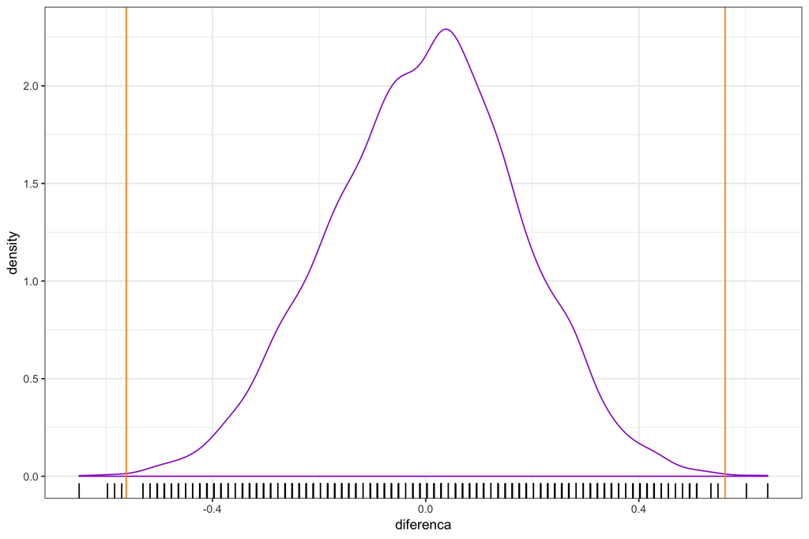

```r
theta_h_vit_emp <- function(df) {
  jogos <- df %>%
    mutate(vit_emp = if_else(p1 == p2, "E", "V")) %>%
    mutate(vit_emp_trocado = sample(vit_emp, n())) %>%
    group_by(vit_emp_trocado) %>%
    summarise(media_gols = mean(gols))

  vitoria <- jogos %>% filter(vit_emp_trocado == "V") %>% pull(media_gols)
  empate <- jogos %>% filter(vit_emp_trocado == "E") %>% pull(media_gols)

  vitoria - empate
}

diffs2 <- replicate(5000, {theta_h_vit_emp(dados)})

tibble(diferenca = diffs2) %>%
  ggplot(mapping = aes(x = diferenca)) +
  #geom_histogram()
  geom_density(fill="white", color = "darkorchid") +
  geom_vline(xintercept = theta_ve, color = "darkorange") +
  geom_vline(xintercept = - theta_ve, color = "darkorange") +
  geom_rug()
```

```r
pvalor2 <- mean(abs(diffs2) >= abs(theta_ve))
```

Sendo 0.0012 o p-valor para a segunda pergunta, podemos ver que é um valor muito pequeno e, portanto, a hipótese nula pode ser rejeitada. O que podemos entender a partir disso é que existe uma diferença significante entre a quantidade de gols quando um dos times vence e quando há um empate.

## Intervalo de Confiança

Observando agora o intervalo de confiança, definiremos uma confiança de 95%, fazendo bootstrap:

### Domingo vs. Quarta

```r
theta_qd <- dados %>% theta_quarta_domingo(1:NROW(dados))

boot_qua_dom <- dados %>% boot::boot(statistic = theta_quarta_domingo, R = 4000) %>%
  broom::tidy(conf.low = 0.95, conf.int = TRUE)

boot_qua_dom
```

```
## # A tibble: 1 x 5
##   statistic     bias std.error conf.low conf.high
##       <dbl>    <dbl>     <dbl>    <dbl>     <dbl>
## 1   -0.0148 -0.00333     0.222   -0.457     0.423
```

### Gols: Empate ou não

```r
theta_ve <- dados %>% theta_vitoria_empate(1:NROW(dados))

boot_vit_emp <- dados %>% boot::boot(statistic = theta_vitoria_empate, R = 4000) %>%
  broom::tidy(conf.low = 0.95, conf.int = TRUE)

boot_vit_emp
```

```
## # A tibble: 1 x 5
##   statistic      bias std.error conf.low conf.high
##       <dbl>     <dbl>     <dbl>    <dbl>     <dbl>
## 1     0.562 -0.000960     0.178    0.217     0.901
```

Diferentemente da pergunta anterior, quando fazemoso bootstrap para esta pergunta, podemos afirmar com bastante certeza que há mais gols numa vitória do que num empate, já que o intervalo é positivo em toda sua extensão. Entretanto, pela diferença menos de um gol, i.e. uma diferença pequena, mas com certeza de haver mais gols em vitórias, é possível entender melhor que o p-valor para a segunda pergunta tenha rejeitado a hipótese nula.